# Lab 1 stuff

## Complex plots

Predict what this code will do. Then run it.

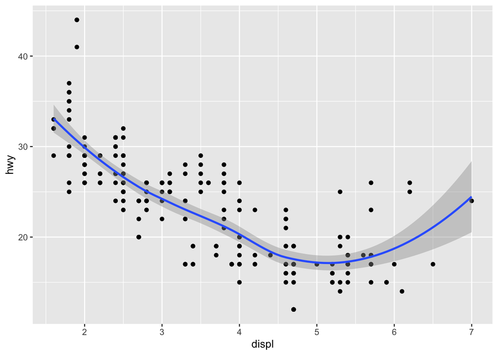

```r
ggplot(mpg) +
  geom_point(aes(displ, hwy)) +
  geom_smooth(aes(displ, hwy))
```

## Fancy completed plot from slides

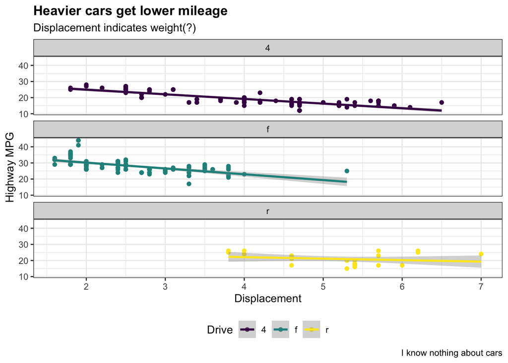

```r
ggplot(data = mpg, mapping = aes(x = displ, y = hwy, color = drv)) +
  geom_point() +
  geom_smooth(method = "lm") +
  scale_color_viridis_d() +
  facet_wrap(vars(drv), ncol = 1) +
  labs(x = "Displacement", y = "Highway MPG",
       color = "Drive",
       title = "Heavier cars get lower mileage",
       subtitle = "Displacement indicates weight(?)",
       caption = "I know nothing about cars") +
  theme_bw() +
  theme(legend.position = "bottom",
        plot.title = element_text(face = "bold"))
```

## Takeaways

You can use this code template to any kind of graph with **ggplot2**.

```r
ggplot(data = <DATA>) +
  <GEOM_FUNCTION>(mapping = aes(<MAPPINGS>))
```

# Manipulating data with dplyr

```r
gapminder <- read_csv("data/gapminder.csv")
```

## gapminder

```r
gapminder
```

```
## # A tibble: 1,704 x 6
##    country     continent  year lifeExp      pop gdpPercap
##    <chr>       <chr>     <dbl>   <dbl>    <dbl>     <dbl>
##  1 Afghanistan Asia       1952    28.8  8425333      779.
##  2 Afghanistan Asia       1957    30.3  9240934      821.
##  3 Afghanistan Asia       1962    32.0 10267083      853.
##  4 Afghanistan Asia       1967    34.0 11537966      836.
##  5 Afghanistan Asia       1972    36.1 13079460      740.
##  6 Afghanistan Asia       1977    38.4 14880372      786.
##  7 Afghanistan Asia       1982    39.9 12881816      978.
##  8 Afghanistan Asia       1987    40.8 13867957      852.
##  9 Afghanistan Asia       1992    41.7 16317921      649.
## 10 Afghanistan Asia       1997    41.8 22227415      635.
## # … with 1,694 more rows
```

## Your turn 1

- `filter()` selects rows based on logical tests

```r
filter(gapminder, country == "New Zealand")
```

```
## # A tibble: 12 x 6
##    country     continent  year lifeExp     pop gdpPercap
##    <chr>       <chr>     <dbl>   <dbl>   <dbl>     <dbl>
##  1 New Zealand Oceania    1952    69.4 1994794    10557.
##  2 New Zealand Oceania    1957    70.3 2229407    12247.
##  3 New Zealand Oceania    1962    71.2 2488550    13176.
##  4 New Zealand Oceania    1967    71.5 2728150    14464.
##  5 New Zealand Oceania    1972    71.9 2929100    16046.
##  6 New Zealand Oceania    1977    72.2 3164900    16234.
##  7 New Zealand Oceania    1982    73.8 3210650    17632.
##  8 New Zealand Oceania    1987    74.3 3317166    19007.
##  9 New Zealand Oceania    1992    76.3 3437674    18363.
## 10 New Zealand Oceania    1997    77.6 3676187    21050.
## 11 New Zealand Oceania    2002    79.1 3908037    23190.
## 12 New Zealand Oceania    2007    80.2 4115771    25185.
```

```r
filter(gapminder, country == "New Zealand")
```

```
## # A tibble: 12 x 6
##    country     continent  year lifeExp     pop gdpPercap
##    <chr>       <chr>     <dbl>   <dbl>   <dbl>     <dbl>
##  1 New Zealand Oceania    1952    69.4 1994794    10557.
##  2 New Zealand Oceania    1957    70.3 2229407    12247.
##  3 New Zealand Oceania    1962    71.2 2488550    13176.
##  4 New Zealand Oceania    1967    71.5 2728150    14464.
##  5 New Zealand Oceania    1972    71.9 2929100    16046.
##  6 New Zealand Oceania    1977    72.2 3164900    16234.
##  7 New Zealand Oceania    1982    73.8 3210650    17632.
##  8 New Zealand Oceania    1987    74.3 3317166    19007.
##  9 New Zealand Oceania    1992    76.3 3437674    18363.
## 10 New Zealand Oceania    1997    77.6 3676187    21050.
## 11 New Zealand Oceania    2002    79.1 3908037    23190.
## 12 New Zealand Oceania    2007    80.2 4115771    25185.
```

```r
filter(gapminder, country == "New Zealand")
```

```
## # A tibble: 12 x 6
##    country     continent  year lifeExp     pop gdpPercap
##    <chr>       <chr>     <dbl>   <dbl>   <dbl>     <dbl>
##  1 New Zealand Oceania    1952    69.4 1994794    10557.
##  2 New Zealand Oceania    1957    70.3 2229407    12247.
##  3 New Zealand Oceania    1962    71.2 2488550    13176.
##  4 New Zealand Oceania    1967    71.5 2728150    14464.
##  5 New Zealand Oceania    1972    71.9 2929100    16046.
##  6 New Zealand Oceania    1977    72.2 3164900    16234.
##  7 New Zealand Oceania    1982    73.8 3210650    17632.
##  8 New Zealand Oceania    1987    74.3 3317166    19007.
##  9 New Zealand Oceania    1992    76.3 3437674    18363.
## 10 New Zealand Oceania    1997    77.6 3676187    21050.
## 11 New Zealand Oceania    2002    79.1 3908037    23190.
## 12 New Zealand Oceania    2007    80.2 4115771    25185.
```

## Your turn 2

```r
filter(gapminder, country == "New Zealand", year > 2000)
```

```
## # A tibble: 2 x 6
##   country     continent  year lifeExp     pop gdpPercap
##   <chr>       <chr>     <dbl>   <dbl>   <dbl>     <dbl>
## 1 New Zealand Oceania    2002    79.1 3908037    23190.
## 2 New Zealand Oceania    2007    80.2 4115771    25185.
```

```r
filter(gapminder, country == "New Zealand", year > 2000)
```

```
## # A tibble: 2 x 6
##   country     continent  year lifeExp     pop gdpPercap
##   <chr>       <chr>     <dbl>   <dbl>   <dbl>     <dbl>
## 1 New Zealand Oceania    2002    79.1 3908037    23190.
## 2 New Zealand Oceania    2007    80.2 4115771    25185.
```

```r
filter(gapminder, country == "New Zealand", year > 2000)
```

```
## # A tibble: 2 x 6
##   country     continent  year lifeExp     pop gdpPercap
##   <chr>       <chr>     <dbl>   <dbl>   <dbl>     <dbl>
## 1 New Zealand Oceania    2002    79.1 3908037    23190.
## 2 New Zealand Oceania    2007    80.2 4115771    25185.
```

## Your turn 3

Write code to:

- Add an `africa` column that is TRUE if the country is on the African continent
- Add a column for logged GDP per capita (hint: use `log()`)
- Add an `africa_asia` column that says “Africa or Asia” if the country is in Africa or Asia, and “Not Africa or Asia” if it’s not

```r
mutate(gapminder)
```

```
## # A tibble: 1,704 x 6
##    country     continent  year lifeExp      pop gdpPercap
##    <chr>       <chr>     <dbl>   <dbl>    <dbl>     <dbl>
##  1 Afghanistan Asia       1952    28.8  8425333      779.
##  2 Afghanistan Asia       1957    30.3  9240934      821.
##  3 Afghanistan Asia       1962    32.0 10267083      853.
##  4 Afghanistan Asia       1967    34.0 11537966      836.
##  5 Afghanistan Asia       1972    36.1 13079460      740.
##  6 Afghanistan Asia       1977    38.4 14880372      786.
##  7 Afghanistan Asia       1982    39.9 12881816      978.
##  8 Afghanistan Asia       1987    40.8 13867957      852.
##  9 Afghanistan Asia       1992    41.7 16317921      649.
## 10 Afghanistan Asia       1997    41.8 22227415      635.
## # … with 1,694 more rows
```

## Your turn 4

Use `summarize()` to compute four statistics about the data:

- The first (minimum) year in the dataset
- The last (maximum) year in the dataset
- The number of rows in the dataset (use the cheatsheet)
- The number of distinct countries in the dataset (use the cheatsheet)

```r
gapminder
```

```
## # A tibble: 1,704 x 6
##    country     continent  year lifeExp      pop gdpPercap
##    <chr>       <chr>     <dbl>   <dbl>    <dbl>     <dbl>
##  1 Afghanistan Asia       1952    28.8  8425333      779.
##  2 Afghanistan Asia       1957    30.3  9240934      821.
##  3 Afghanistan Asia       1962    32.0 10267083      853.
##  4 Afghanistan Asia       1967    34.0 11537966      836.
##  5 Afghanistan Asia       1972    36.1 13079460      740.
##  6 Afghanistan Asia       1977    38.4 14880372      786.
##  7 Afghanistan Asia       1982    39.9 12881816      978.
##  8 Afghanistan Asia       1987    40.8 13867957      852.
##  9 Afghanistan Asia       1992    41.7 16317921      649.
## 10 Afghanistan Asia       1997    41.8 22227415      635.
## # … with 1,694 more rows
```

## Your turn 5

Use `filter()` and `summarize()` to calculate the (1) the number of unique countries and (2) the median life expectancy on the African continent in 2007.

```r
gapminder
```

```
## # A tibble: 1,704 x 6
##    country     continent  year lifeExp      pop gdpPercap
##    <chr>       <chr>     <dbl>   <dbl>    <dbl>     <dbl>
##  1 Afghanistan Asia       1952    28.8  8425333      779.
##  2 Afghanistan Asia       1957    30.3  9240934      821.
##  3 Afghanistan Asia       1962    32.0 10267083      853.
##  4 Afghanistan Asia       1967    34.0 11537966      836.
##  5 Afghanistan Asia       1972    36.1 13079460      740.
##  6 Afghanistan Asia       1977    38.4 14880372      786.
##  7 Afghanistan Asia       1982    39.9 12881816      978.
##  8 Afghanistan Asia       1987    40.8 13867957      852.
##  9 Afghanistan Asia       1992    41.7 16317921      649.
## 10 Afghanistan Asia       1997    41.8 22227415      635.
## # … with 1,694 more rows
```

## Your turn 6

Find the minimum, maximum, and median life expectancy for each continent.

```r
gapminder
```

```
## # A tibble: 1,704 x 6
##    country     continent  year lifeExp      pop gdpPercap
##    <chr>       <chr>     <dbl>   <dbl>    <dbl>     <dbl>
##  1 Afghanistan Asia       1952    28.8  8425333      779.
##  2 Afghanistan Asia       1957    30.3  9240934      821.
##  3 Afghanistan Asia       1962    32.0 10267083      853.
##  4 Afghanistan Asia       1967    34.0 11537966      836.
##  5 Afghanistan Asia       1972    36.1 13079460      740.
##  6 Afghanistan Asia       1977    38.4 14880372      786.
##  7 Afghanistan Asia       1982    39.9 12881816      978.
##  8 Afghanistan Asia       1987    40.8 13867957      852.
##  9 Afghanistan Asia       1992    41.7 16317921      649.
## 10 Afghanistan Asia       1997    41.8 22227415      635.
## # … with 1,694 more rows
```

Find the minimum, maximum, and median life expectancy for each continent in 2007 only.

```r
gapminder
```

```
## # A tibble: 1,704 x 6
##    country     continent  year lifeExp      pop gdpPercap
##    <chr>       <chr>     <dbl>   <dbl>    <dbl>     <dbl>
##  1 Afghanistan Asia       1952    28.8  8425333      779.
##  2 Afghanistan Asia       1957    30.3  9240934      821.
##  3 Afghanistan Asia       1962    32.0 10267083      853.
##  4 Afghanistan Asia       1967    34.0 11537966      836.
##  5 Afghanistan Asia       1972    36.1 13079460      740.
##  6 Afghanistan Asia       1977    38.4 14880372      786.
##  7 Afghanistan Asia       1982    39.9 12881816      978.
##  8 Afghanistan Asia       1987    40.8 13867957      852.
##  9 Afghanistan Asia       1992    41.7 16317921      649.
## 10 Afghanistan Asia       1997    41.8 22227415      635.
## # … with 1,694 more rows
```